# Exercise 3

# Solution with the `tidyverse` (mainly `dplyr`)

Let’s load the tidyverse and read in the data:

```r
library(tidyverse)
rawdata <- read_csv("CentreCountyPrecinctResults2016GeneralElection.txt")
rawdata
```

| County | ElecYear | Election | ElecDate | PrecNo | PrecName | Party | Contest | Descr | VoteFor | Candidate | Posn | Count | PctCnt | Total | PctTot |
| --- | --- | --- | --- | --- | --- | --- | --- | --- | --- | --- | --- | --- | --- | --- | --- |
| CENTRE COUNTY, PENNSYLVANIA | 2016 | GENERAL ELECTION | NOVEMBER 8 2016 | 0001 | 01 BELLEFONTE NORTH | NA | REGISTERED VOTERS - TOTAL | NA | NA | NA | 10 | 507 | NA | NA | NA |
| CENTRE COUNTY, PENNSYLVANIA | 2016 | GENERAL ELECTION | NOVEMBER 8 2016 | 0001 | 01 BELLEFONTE NORTH | NA | BALLOTS CAST - TOTAL | NA | NA | NA | 11 | 391 | NA | NA | NA |
| CENTRE COUNTY, PENNSYLVANIA | 2016 | GENERAL ELECTION | NOVEMBER 8 2016 | 0001 | 01 BELLEFONTE NORTH | NA | VOTER TURNOUT - TOTAL | NA | NA | NA | 12 | NA | 77.12 | NA | NA |
| CENTRE COUNTY, PENNSYLVANIA | 2016 | GENERAL ELECTION | NOVEMBER 8 2016 | 0001 | 01 BELLEFONTE NORTH | DEMOCRATIC | STRAIGHT PARTY | NA | VOTE FOR NOT MORE THAN 1 | DEMOCRATIC | 17 | 46 | 40.35 | NA | NA |
| CENTRE COUNTY, PENNSYLVANIA | 2016 | GENERAL ELECTION | NOVEMBER 8 2016 | 0001 | 01 BELLEFONTE NORTH | REPUBLICAN | STRAIGHT PARTY | NA | VOTE FOR NOT MORE THAN 1 | REPUBLICAN | 18 | 66 | 57.89 | NA | NA |
| CENTRE COUNTY, PENNSYLVANIA | 2016 | GENERAL ELECTION | NOVEMBER 8 2016 | 0001 | 01 BELLEFONTE NORTH | CONSTITUTION PARTY | STRAIGHT PARTY | NA | VOTE FOR NOT MORE THAN 1 | CONSTITUTION PARTY | 19 | 0 | NA | NA | NA |
| CENTRE COUNTY, PENNSYLVANIA | 2016 | GENERAL ELECTION | NOVEMBER 8 2016 | 0001 | 01 BELLEFONTE NORTH | GREEN | STRAIGHT PARTY | NA | VOTE FOR NOT MORE THAN 1 | GREEN | 20 | 1 | 0.88 | NA | NA |
| CENTRE COUNTY, PENNSYLVANIA | 2016 | GENERAL ELECTION | NOVEMBER 8 2016 | 0001 | 01 BELLEFONTE NORTH | LIBERTARIAN | STRAIGHT PARTY | NA | VOTE FOR NOT MORE THAN 1 | LIBERTARIAN | 21 | 1 | 0.88 | NA | NA |
| CENTRE COUNTY, PENNSYLVANIA | 2016 | GENERAL ELECTION | NOVEMBER 8 2016 | 0001 | 01 BELLEFONTE NORTH | DEMOCRATIC | PRESIDENTIAL ELECTORS | NA | VOTE FOR NOT MORE THAN 1 | HILLARY CLINTON, PRESIDENT | 26 | 188 | 48.08 | NA | NA |
| CENTRE COUNTY, PENNSYLVANIA | 2016 | GENERAL ELECTION | NOVEMBER 8 2016 | 0001 | 01 BELLEFONTE NORTH | REPUBLICAN | PRESIDENTIAL ELECTORS | NA | VOTE FOR NOT MORE THAN 1 | DONALD J TRUMP, PRESIDENT | 27 | 174 | 44.50 | NA | NA |

[output cut: 990 more lines]

This solution creates three dataframes that it joins together in the last step: the total votes, the two-party shares, and the rolloffs. Each of these dataframes should ultimately have 91 rows.

### Total vote table

The total vote numbers are already in the data, we just need to `filter` rows down to just the 91 we need, and then `select` the columns we need.

```r
Tot <- rawdata %>%
  filter(Contest=="BALLOTS CAST - TOTAL") %>% # filter to the rows with total votes
  select(PrecNo,PrecName,Tot=Count) #select the id columns and the counts. Rename the counts to Tot
Tot
```

| PrecNo | PrecName | Tot |
| --- | --- | --- |
| 0001 | 01 BELLEFONTE NORTH | 391 |
| 0002 | 02 BELLEFONTE NORTHEAST | 687 |
| 0003 | 03 BELLEFONTE SOUTH | 461 |
| 0004 | 04 BELLEFONTE SOUTHEAST | 718 |
| 0005 | 05 BELLEFONTE WEST | 928 |
| 0006 | 06 CENTRE HALL | 709 |
| 0007 | 07 HOWARD BORO | 377 |
| 0008 | 08 MILESBURG | 525 |
| 0009 | 09 MILLHEIM | 423 |
| 0010 | 10 PHILIPSBURG 1ST WARD | 449 |

[output cut: 81 more lines]

### Ballot rolloff

Now we’ll calculate the rolloff data. Ultimately, the output is 91 rows, 1 row per precinct, with four columns containing the rolloff in the non-presidential races in that precinct. To get there, we need an intermediate table of 91 rows with the total votes per statewide contest, including President, by precinct. So the trickiest step is the one where we `spread’ the data from its “long” format to a “wide” format with these variables.

The following code is presented as one long pipeline with one input and one output. The identical code is repeated below in this notebook, with output printed for each intermediate step.

```r
Rolloffs <- rawdata %>%                  # Start with the raw data
  select(PrecNo, Contest, Count) %>%     # For rolloff we need the data by precinct & contest
  mutate(Con=substr(Contest,1,3)) %>%    # For cleanliness, create an abbreviated contest variable
  filter(Con %in% c("PRE","UNI","ATT","AUD","STA")) %>%  # Pick the rows with just the statewide contests
  group_by(PrecNo,Con) %>%               # Group into Precinct-Contest units
  summarise(ConTot=sum(Count)) %>%       # Calculate total vote by Precinct-Contest
  spread(Con, ConTot) %>%               # Spread the data by Contest
  mutate(ROSen=100*(1-UNI/PRE),         # Rolloff for Senator (UNI TED STATES SENATOR)
         ROAtt=100*(1-ATT/PRE),         # Rolloff for Attorney General (ATT ORNEY GENERAL)
         ROAud=100*(1-AUD/PRE),         # Rolloff for Auditor General (AUD ITOR GENERAL)
         ROTre=100*(1-STA/PRE)) %>%     # Rolloff for Treasurer (STA TE TREASURER)
  select(PrecNo,ROSen,ROAtt,ROAud,ROTre) # Keep just the Precinct Number and Rolloff variables
Rolloffs
```

| PrecNo | ROSen | ROAtt | ROAud | ROTre |
| --- | --- | --- | --- | --- |
| 0001 | 1.27877238 | 2.3017903 | 6.9053708 | 5.882353 |
| 0002 | 0.58910162 | 1.6200295 | 3.2400589 | 3.534610 |
| 0003 | 1.09409190 | 1.3129103 | 1.9693654 | 2.188184 |
| 0004 | 1.25523013 | 3.3472803 | 4.4630404 | 5.020921 |
| 0005 | 1.19305857 | 2.0607375 | 3.3622560 | 3.253796 |
| 0006 | 0.84865629 | 1.9801980 | 3.2531825 | 3.818953 |
| 0007 | 0.79575597 | 1.8567639 | 1.8567639 | 2.387268 |
| 0008 | 2.49042146 | 2.6819923 | 4.2145594 | 4.214559 |
| 0009 | 0.71258907 | 1.1876485 | 2.1377672 | 2.612827 |
| 0010 | 0.89686099 | 2.2421525 | 2.9147982 | 3.811659 |

[output cut: 81 more lines]

### Democratic Share of Two-Party Vote

This is similar to rolloff in that we need to calculate two intermediate quantities along the way: total vote for Republican and Democrat in each race, by precinct. With rolloff, we needed to spread the data to create contest data by precinct. With party shares, we need to spread the data to create contest-party data by precinct, so we need to create a contest-party key indicator variable before spreading.

```r
DemTwoPartyVotes <- rawdata %>%            # Start with the raw data
  select(PrecNo,Party,Contest,Count) %>%   # All we need is Precinct, the "Contest", and the "Count"
  mutate(Con=substr(Contest,1,3),Pty=substr(Party,1,3)) %>% # Create abbreviated Party & Contest variables
  select(PrecNo,Pty,Con,Count) %>%         # Get rid of the unabbreviated variables
  filter(Con %in% c("PRE","UNI","ATT","AUD","STA")) %>%  # Pick just the rows with elections of interest
  filter(Pty %in% c('DEM','REP')) %>%      # Pick just Democratic and Republican candidates
  mutate(ConPty = paste(Con,Pty,sep="")) %>%  #### CREATE CONTEST-PARTY TO ACT AS KEY FOR SPREAD
  select(PrecNo,ConPty,Count) %>%          # Get rid of columns we don't need.
  spread(ConPty,Count) %>%                 ##### SPREAD THE DATA BY THE CONTEST-PARTY KEY
  mutate(D2Pre=100*(PREDEM/(PREDEM+PREREP)),     # D2Pre = Dem share of 2 party vote for President
         D2Sen=100*(UNIDEM/(UNIDEM+UNIREP)),     # D2Sen = Dem share of 2 party vote for US Senator
         D2Att=100*(ATTDEM/(ATTDEM+ATTREP)),     # D2Att = Dem share of 2 party vote for Attorney Genl
         D2Aud=100*(AUDDEM/(AUDDEM+AUDREP)),     # D2Aud = Dem share of 2 party vote for Auditor Genl
         D2Tre=100*(STADEM/(STADEM+STAREP))) %>% # D2Tre = Dem share of 2 party vote for St Treasurer
  select(PrecNo,D2Pre,D2Sen,D2Att,D2Aud,D2Tre)  # Get rid of columns we don't need
DemTwoPartyVotes
```

| PrecNo | D2Pre | D2Sen | D2Att | D2Aud | D2Tre |
| --- | --- | --- | --- | --- | --- |
| 0001 | 51.93370 | 47.74011 | 50.91864 | 51.05105 | 51.90616 |
| 0002 | 40.21739 | 39.40345 | 39.78979 | 42.71845 | 42.28188 |
| 0003 | 54.37352 | 54.52381 | 57.33333 | 58.19071 | 57.53769 |
| 0004 | 43.00912 | 43.07458 | 44.50867 | 47.43590 | 44.51827 |
| 0005 | 52.67539 | 53.39806 | 55.38291 | 58.40708 | 58.32274 |
| 0006 | 34.17533 | 37.40219 | 40.11544 | 39.84375 | 40.65041 |
| 0007 | 34.85714 | 36.25731 | 37.02703 | 41.01796 | 40.30769 |
| 0008 | 28.88889 | 35.98234 | 38.38583 | 39.01919 | 40.04329 |
| 0009 | 42.03980 | 43.58974 | 44.71154 | 51.70604 | 50.41551 |
| 0010 | 37.50000 | 39.47368 | 38.24885 | 44.25428 | 44.72362 |

[output cut: 81 more lines]

### Merged Data

Now we merge the tables and format the Precinct Number and Name as requested in the Exercise. The main verb here is `*_join.` Any of `left_join`, `right_join`, or `inner_join` will work in this case to match data from each table by the only matching variable, PrecNo. (These verbs differ in how they treat rows in which the join variables are missing or duplicated in one or the other table, but in this case all three tables have exactly 91 rows with unique PrecNo, so the effect is identical.)

```r
Ex3Data <- Tot %>%                            # Start with the Tot data_frame
  left_join(DemTwoPartyVotes) %>%             # Merge the DemTwoParty table (on shared PrecNo)
  left_join(Rolloffs) %>%                     # Merge the Rolloff table (on shared PrecNo)
  mutate(PrecNo=as.integer(PrecNo)) %>%       # Turn PrecNo into a number
  mutate(PrecName=str_sub(PrecName,start=4L)) # Strip the redundant number off of the Precinct names
Ex3Data
```

| PrecNo | PrecName | Tot | D2Pre | D2Sen | D2Att | D2Aud | D2Tre | ROSen | ROAtt | ROAud | ROTre |
| --- | --- | --- | --- | --- | --- | --- | --- | --- | --- | --- | --- |
| 1 | BELLEFONTE NORTH | 391 | 51.93370 | 47.74011 | 50.91864 | 51.05105 | 51.90616 | 1.27877238 | 2.3017903 | 6.9053708 | 5.882353 |
| 2 | BELLEFONTE NORTHEAST | 687 | 40.21739 | 39.40345 | 39.78979 | 42.71845 | 42.28188 | 0.58910162 | 1.6200295 | 3.2400589 | 3.534610 |
| 3 | BELLEFONTE SOUTH | 461 | 54.37352 | 54.52381 | 57.33333 | 58.19071 | 57.53769 | 1.09409190 | 1.3129103 | 1.9693654 | 2.188184 |
| 4 | BELLEFONTE SOUTHEAST | 718 | 43.00912 | 43.07458 | 44.50867 | 47.43590 | 44.51827 | 1.25523013 | 3.3472803 | 4.4630404 | 5.020921 |
| 5 | BELLEFONTE WEST | 928 | 52.67539 | 53.39806 | 55.38291 | 58.40708 | 58.32274 | 1.19305857 | 2.0607375 | 3.3622560 | 3.253796 |
| 6 | CENTRE HALL | 709 | 34.17533 | 37.40219 | 40.11544 | 39.84375 | 40.65041 | 0.84865629 | 1.9801980 | 3.2531825 | 3.818953 |
| 7 | HOWARD BORO | 377 | 34.85714 | 36.25731 | 37.02703 | 41.01796 | 40.30769 | 0.79575597 | 1.8567639 | 1.8567639 | 2.387268 |
| 8 | MILESBURG | 525 | 28.88889 | 35.98234 | 38.38583 | 39.01919 | 40.04329 | 2.49042146 | 2.6819923 | 4.2145594 | 4.214559 |
| 9 | MILLHEIM | 423 | 42.03980 | 43.58974 | 44.71154 | 51.70604 | 50.41551 | 0.71258907 | 1.1876485 | 2.1377672 | 2.612827 |
| 10 | PHILIPSBURG 1ST WARD | 449 | 37.50000 | 39.47368 | 38.24885 | 44.25428 | 44.72362 | 0.89686099 | 2.2421525 | 2.9147982 | 3.811659 |

[output cut: 81 more lines]

### With intermediate steps

Here we repeat the exact steps from above, but with a “print” statement at each step to see all of the intermediate results.

```r
Tot <- rawdata %>%
  filter(Contest=="BALLOTS CAST - TOTAL") %T>% print()  %>% # filter to the rows with total votes
  select(PrecNo,PrecName,Tot=Count) #select the id columns and the counts. Rename the counts to Tot
```

| County | ElecYear | Election | ElecDate | PrecNo | PrecName | Party | Contest | Descr | VoteFor | Candidate | Posn | Count | PctCnt | Total | PctTot |
| --- | --- | --- | --- | --- | --- | --- | --- | --- | --- | --- | --- | --- | --- | --- | --- |
| CENTRE COUNTY, PENNSYLVANIA | 2016 | GENERAL ELECTION | NOVEMBER 8 2016 | 0001 | 01 BELLEFONTE NORTH | NA | BALLOTS CAST - TOTAL | NA | NA | NA | 11 | 391 | NA | NA | NA |
| CENTRE COUNTY, PENNSYLVANIA | 2016 | GENERAL ELECTION | NOVEMBER 8 2016 | 0002 | 02 BELLEFONTE NORTHEAST | NA | BALLOTS CAST - TOTAL | NA | NA | NA | 96 | 687 | NA | NA | NA |
| CENTRE COUNTY, PENNSYLVANIA | 2016 | GENERAL ELECTION | NOVEMBER 8 2016 | 0003 | 03 BELLEFONTE SOUTH | NA | BALLOTS CAST - TOTAL | NA | NA | NA | 181 | 461 | NA | NA | NA |
| CENTRE COUNTY, PENNSYLVANIA | 2016 | GENERAL ELECTION | NOVEMBER 8 2016 | 0004 | 04 BELLEFONTE SOUTHEAST | NA | BALLOTS CAST - TOTAL | NA | NA | NA | 266 | 718 | NA | NA | NA |
| CENTRE COUNTY, PENNSYLVANIA | 2016 | GENERAL ELECTION | NOVEMBER 8 2016 | 0005 | 05 BELLEFONTE WEST | NA | BALLOTS CAST - TOTAL | NA | NA | NA | 351 | 928 | NA | NA | NA |
| CENTRE COUNTY, PENNSYLVANIA | 2016 | GENERAL ELECTION | NOVEMBER 8 2016 | 0006 | 06 CENTRE HALL | NA | BALLOTS CAST - TOTAL | NA | NA | NA | 436 | 709 | NA | NA | NA |
| CENTRE COUNTY, PENNSYLVANIA | 2016 | GENERAL ELECTION | NOVEMBER 8 2016 | 0007 | 07 HOWARD BORO | NA | BALLOTS CAST - TOTAL | NA | NA | NA | 521 | 377 | NA | NA | NA |
| CENTRE COUNTY, PENNSYLVANIA | 2016 | GENERAL ELECTION | NOVEMBER 8 2016 | 0008 | 08 MILESBURG | NA | BALLOTS CAST - TOTAL | NA | NA | NA | 606 | 525 | NA | NA | NA |
| CENTRE COUNTY, PENNSYLVANIA | 2016 | GENERAL ELECTION | NOVEMBER 8 2016 | 0009 | 09 MILLHEIM | NA | BALLOTS CAST - TOTAL | NA | NA | NA | 691 | 423 | NA | NA | NA |
| CENTRE COUNTY, PENNSYLVANIA | 2016 | GENERAL ELECTION | NOVEMBER 8 2016 | 0010 | 10 PHILIPSBURG 1ST WARD | NA | BALLOTS CAST - TOTAL | NA | NA | NA | 776 | 449 | NA | NA | NA |

[output cut: 81 more lines]

```r
Tot
```

| PrecNo | PrecName | Tot |
| --- | --- | --- |
| 0001 | 01 BELLEFONTE NORTH | 391 |
| 0002 | 02 BELLEFONTE NORTHEAST | 687 |
| 0003 | 03 BELLEFONTE SOUTH | 461 |
| 0004 | 04 BELLEFONTE SOUTHEAST | 718 |
| 0005 | 05 BELLEFONTE WEST | 928 |
| 0006 | 06 CENTRE HALL | 709 |
| 0007 | 07 HOWARD BORO | 377 |
| 0008 | 08 MILESBURG | 525 |
| 0009 | 09 MILLHEIM | 423 |
| 0010 | 10 PHILIPSBURG 1ST WARD | 449 |

[output cut: 81 more lines]

```r
Rolloffs <- rawdata %>%                  # Start with the raw data
  select(PrecNo, Contest, Count) %T>% print()  %>%  # For rolloff we need the data by precinct & contest
  mutate(Con=substr(Contest,1,3)) %T>% print()  %>% # For cleanliness, create abbreviated contest variable
  filter(Con %in% c("PRE","UNI","ATT","AUD","STA")) %T>% print() %>% # Pick the rows w statewide contests
  group_by(PrecNo,Con) %T>% print() %>%               # Group into Precinct-Contest units
  summarise(ConTot=sum(Count)) %T>% print() %>%       # Calculate total vote by Precinct-Contest
  spread(Con, ConTot) %>%               # Spread the data by Contest
  mutate(ROSen=100*(1-UNI/PRE),         # Rolloff for Senator (UNI TED STATES SENATOR)
         ROAtt=100*(1-ATT/PRE),         # Rolloff for Attorney General (ATT ORNEY GENERAL)
         ROAud=100*(1-AUD/PRE),         # Rolloff for Auditor General (AUD ITOR GENERAL)
         ROTre=100*(1-STA/PRE)) %T>% print()  %>%     # Rolloff for Treasurer (STA TE TREASURER)
  select(PrecNo,ROSen,ROAtt,ROAud,ROTre) # Keep just the Precinct Number and Rolloff variables
```

| PrecNo | Contest | Count |
| --- | --- | --- |
| 0001 | REGISTERED VOTERS - TOTAL | 507 |
| 0001 | BALLOTS CAST - TOTAL | 391 |
| 0001 | VOTER TURNOUT - TOTAL | NA |
| 0001 | STRAIGHT PARTY | 46 |
| 0001 | STRAIGHT PARTY | 66 |
| 0001 | STRAIGHT PARTY | 0 |
| 0001 | STRAIGHT PARTY | 1 |
| 0001 | STRAIGHT PARTY | 1 |
| 0001 | PRESIDENTIAL ELECTORS | 188 |
| 0001 | PRESIDENTIAL ELECTORS | 174 |

[output cut: 990 more lines]

| PrecNo | Contest | Count | Con |
| --- | --- | --- | --- |
| 0001 | REGISTERED VOTERS - TOTAL | 507 | REG |
| 0001 | BALLOTS CAST - TOTAL | 391 | BAL |
| 0001 | VOTER TURNOUT - TOTAL | NA | VOT |
| 0001 | STRAIGHT PARTY | 46 | STR |
| 0001 | STRAIGHT PARTY | 66 | STR |
| 0001 | STRAIGHT PARTY | 0 | STR |
| 0001 | STRAIGHT PARTY | 1 | STR |
| 0001 | STRAIGHT PARTY | 1 | STR |
| 0001 | PRESIDENTIAL ELECTORS | 188 | PRE |
| 0001 | PRESIDENTIAL ELECTORS | 174 | PRE |

[output cut: 990 more lines]

| PrecNo | Contest | Count | Con |
| --- | --- | --- | --- |
| 0001 | PRESIDENTIAL ELECTORS | 188 | PRE |
| 0001 | PRESIDENTIAL ELECTORS | 174 | PRE |
| 0001 | PRESIDENTIAL ELECTORS | 2 | PRE |
| 0001 | PRESIDENTIAL ELECTORS | 3 | PRE |
| 0001 | PRESIDENTIAL ELECTORS | 22 | PRE |
| 0001 | PRESIDENTIAL ELECTORS | 2 | PRE |
| 0001 | UNITED STATES SENATOR | 169 | UNI |
| 0001 | UNITED STATES SENATOR | 185 | UNI |
| 0001 | UNITED STATES SENATOR | 31 | UNI |
| 0001 | UNITED STATES SENATOR | 1 | UNI |

[output cut: 990 more lines]

| PrecNo | Contest | Count | Con |
| --- | --- | --- | --- |
| 0001 | PRESIDENTIAL ELECTORS | 188 | PRE |
| 0001 | PRESIDENTIAL ELECTORS | 174 | PRE |
| 0001 | PRESIDENTIAL ELECTORS | 2 | PRE |
| 0001 | PRESIDENTIAL ELECTORS | 3 | PRE |
| 0001 | PRESIDENTIAL ELECTORS | 22 | PRE |
| 0001 | PRESIDENTIAL ELECTORS | 2 | PRE |
| 0001 | UNITED STATES SENATOR | 169 | UNI |
| 0001 | UNITED STATES SENATOR | 185 | UNI |
| 0001 | UNITED STATES SENATOR | 31 | UNI |
| 0001 | UNITED STATES SENATOR | 1 | UNI |

[output cut: 990 more lines]

| PrecNo | Con | ConTot |
| --- | --- | --- |
| 0001 | ATT | 382 |
| 0001 | AUD | 364 |
| 0001 | PRE | 391 |
| 0001 | STA | 368 |
| 0001 | UNI | 386 |
| 0002 | ATT | 668 |
| 0002 | AUD | 657 |
| 0002 | PRE | 679 |
| 0002 | STA | 655 |
| 0002 | UNI | 675 |

[output cut: 445 more lines]

| PrecNo | ATT | AUD | PRE | STA | UNI | ROSen | ROAtt | ROAud | ROTre |
| --- | --- | --- | --- | --- | --- | --- | --- | --- | --- |
| 0001 | 382 | 364 | 391 | 368 | 386 | 1.27877238 | 2.3017903 | 6.9053708 | 5.882353 |
| 0002 | 668 | 657 | 679 | 655 | 675 | 0.58910162 | 1.6200295 | 3.2400589 | 3.534610 |
| 0003 | 451 | 448 | 457 | 447 | 452 | 1.09409190 | 1.3129103 | 1.9693654 | 2.188184 |
| 0004 | 693 | 685 | 717 | 681 | 708 | 1.25523013 | 3.3472803 | 4.4630404 | 5.020921 |
| 0005 | 903 | 891 | 922 | 892 | 911 | 1.19305857 | 2.0607375 | 3.3622560 | 3.253796 |
| 0006 | 693 | 684 | 707 | 680 | 701 | 0.84865629 | 1.9801980 | 3.2531825 | 3.818953 |
| 0007 | 370 | 370 | 377 | 368 | 374 | 0.79575597 | 1.8567639 | 1.8567639 | 2.387268 |
| 0008 | 508 | 500 | 522 | 500 | 509 | 2.49042146 | 2.6819923 | 4.2145594 | 4.214559 |
| 0009 | 416 | 412 | 421 | 410 | 418 | 0.71258907 | 1.1876485 | 2.1377672 | 2.612827 |
| 0010 | 436 | 433 | 446 | 429 | 442 | 0.89686099 | 2.2421525 | 2.9147982 | 3.811659 |

[output cut: 81 more lines]

```r
Rolloffs
```

| PrecNo | ROSen | ROAtt | ROAud | ROTre |
| --- | --- | --- | --- | --- |
| 0001 | 1.27877238 | 2.3017903 | 6.9053708 | 5.882353 |
| 0002 | 0.58910162 | 1.6200295 | 3.2400589 | 3.534610 |
| 0003 | 1.09409190 | 1.3129103 | 1.9693654 | 2.188184 |
| 0004 | 1.25523013 | 3.3472803 | 4.4630404 | 5.020921 |
| 0005 | 1.19305857 | 2.0607375 | 3.3622560 | 3.253796 |
| 0006 | 0.84865629 | 1.9801980 | 3.2531825 | 3.818953 |
| 0007 | 0.79575597 | 1.8567639 | 1.8567639 | 2.387268 |
| 0008 | 2.49042146 | 2.6819923 | 4.2145594 | 4.214559 |
| 0009 | 0.71258907 | 1.1876485 | 2.1377672 | 2.612827 |
| 0010 | 0.89686099 | 2.2421525 | 2.9147982 | 3.811659 |

[output cut: 81 more lines]

```r
DemTwoPartyVotes <- rawdata %>%            # Start with the raw data
  select(PrecNo,Party,Contest,Count) %T>% print() %>%   # All we need is Precinct, Contest, & "Count"
  mutate(Con=substr(Contest,1,3),Pty=substr(Party,1,3)) %T>% print() %>% # Abbreviated Party & Contest
  select(PrecNo,Pty,Con,Count) %T>% print() %>%         # Get rid of the unabbreviated variables
  filter(Con %in% c("PRE","UNI","ATT","AUD","STA")) %T>% print() %>%  # Pick rows w elections of interest
  filter(Pty %in% c('DEM','REP')) %T>% print() %>%      # Pick just Democratic and Republican candidates
  mutate(ConPty = paste(Con,Pty,sep="")) %T>% print() %>%  #### CREATE CONTEST-PARTY AS KEY FOR SPREAD
  select(PrecNo,ConPty,Count) %T>% print() %>%          # Get rid of columns we don't need.
  spread(ConPty,Count) %T>% print() %>%                 ##### SPREAD THE DATA BY THE CONTEST-PARTY KEY
  mutate(D2Pre=100*(PREDEM/(PREDEM+PREREP)),     # D2Pre = Dem share of 2 party vote for President
         D2Sen=100*(UNIDEM/(UNIDEM+UNIREP)),     # D2Sen = Dem share of 2 party vote for US Senator
         D2Att=100*(ATTDEM/(ATTDEM+ATTREP)),     # D2Att = Dem share of 2 party vote for Attorney Genl
         D2Aud=100*(AUDDEM/(AUDDEM+AUDREP)),     # D2Aud = Dem share of 2 party vote for Auditor Genl
         D2Tre=100*(STADEM/(STADEM+STAREP))) %T>% print() %>% # D2Tre = Dem share, 2 pty vote St Treasurer
  select(PrecNo,D2Pre,D2Sen,D2Att,D2Aud,D2Tre)  # Get rid of columns we don't need
```

| PrecNo | Party | Contest | Count |
| --- | --- | --- | --- |
| 0001 | NA | REGISTERED VOTERS - TOTAL | 507 |
| 0001 | NA | BALLOTS CAST - TOTAL | 391 |
| 0001 | NA | VOTER TURNOUT - TOTAL | NA |
| 0001 | DEMOCRATIC | STRAIGHT PARTY | 46 |
| 0001 | REPUBLICAN | STRAIGHT PARTY | 66 |
| 0001 | CONSTITUTION PARTY | STRAIGHT PARTY | 0 |
| 0001 | GREEN | STRAIGHT PARTY | 1 |
| 0001 | LIBERTARIAN | STRAIGHT PARTY | 1 |
| 0001 | DEMOCRATIC | PRESIDENTIAL ELECTORS | 188 |
| 0001 | REPUBLICAN | PRESIDENTIAL ELECTORS | 174 |

[output cut: 990 more lines]

| PrecNo | Party | Contest | Count | Con | Pty |
| --- | --- | --- | --- | --- | --- |
| 0001 | NA | REGISTERED VOTERS - TOTAL | 507 | REG | NA |
| 0001 | NA | BALLOTS CAST - TOTAL | 391 | BAL | NA |
| 0001 | NA | VOTER TURNOUT - TOTAL | NA | VOT | NA |
| 0001 | DEMOCRATIC | STRAIGHT PARTY | 46 | STR | DEM |
| 0001 | REPUBLICAN | STRAIGHT PARTY | 66 | STR | REP |
| 0001 | CONSTITUTION PARTY | STRAIGHT PARTY | 0 | STR | CON |
| 0001 | GREEN | STRAIGHT PARTY | 1 | STR | GRE |
| 0001 | LIBERTARIAN | STRAIGHT PARTY | 1 | STR | LIB |
| 0001 | DEMOCRATIC | PRESIDENTIAL ELECTORS | 188 | PRE | DEM |
| 0001 | REPUBLICAN | PRESIDENTIAL ELECTORS | 174 | PRE | REP |

[output cut: 990 more lines]

| PrecNo | Pty | Con | Count |
| --- | --- | --- | --- |
| 0001 | NA | REG | 507 |
| 0001 | NA | BAL | 391 |
| 0001 | NA | VOT | NA |
| 0001 | DEM | STR | 46 |
| 0001 | REP | STR | 66 |
| 0001 | CON | STR | 0 |
| 0001 | GRE | STR | 1 |
| 0001 | LIB | STR | 1 |
| 0001 | DEM | PRE | 188 |
| 0001 | REP | PRE | 174 |

[output cut: 990 more lines]

| PrecNo | Pty | Con | Count |
| --- | --- | --- | --- |
| 0001 | DEM | PRE | 188 |
| 0001 | REP | PRE | 174 |
| 0001 | CON | PRE | 2 |
| 0001 | GRE | PRE | 3 |
| 0001 | LIB | PRE | 22 |
| 0001 | NA | PRE | 2 |
| 0001 | DEM | UNI | 169 |
| 0001 | REP | UNI | 185 |
| 0001 | LIB | UNI | 31 |
| 0001 | NA | UNI | 1 |

[output cut: 990 more lines]

| PrecNo | Pty | Con | Count |
| --- | --- | --- | --- |
| 0001 | DEM | PRE | 188 |
| 0001 | REP | PRE | 174 |
| 0001 | DEM | UNI | 169 |
| 0001 | REP | UNI | 185 |
| 0001 | DEM | ATT | 194 |
| 0001 | REP | ATT | 187 |
| 0001 | DEM | AUD | 170 |
| 0001 | REP | AUD | 163 |
| 0001 | DEM | STA | 177 |
| 0001 | REP | STA | 164 |

[output cut: 900 more lines]

| PrecNo | Pty | Con | Count | ConPty |
| --- | --- | --- | --- | --- |
| 0001 | DEM | PRE | 188 | PREDEM |
| 0001 | REP | PRE | 174 | PREREP |
| 0001 | DEM | UNI | 169 | UNIDEM |
| 0001 | REP | UNI | 185 | UNIREP |
| 0001 | DEM | ATT | 194 | ATTDEM |
| 0001 | REP | ATT | 187 | ATTREP |
| 0001 | DEM | AUD | 170 | AUDDEM |
| 0001 | REP | AUD | 163 | AUDREP |
| 0001 | DEM | STA | 177 | STADEM |
| 0001 | REP | STA | 164 | STAREP |

[output cut: 900 more lines]

| PrecNo | ConPty | Count |
| --- | --- | --- |
| 0001 | PREDEM | 188 |
| 0001 | PREREP | 174 |
| 0001 | UNIDEM | 169 |
| 0001 | UNIREP | 185 |
| 0001 | ATTDEM | 194 |
| 0001 | ATTREP | 187 |
| 0001 | AUDDEM | 170 |
| 0001 | AUDREP | 163 |
| 0001 | STADEM | 177 |
| 0001 | STAREP | 164 |

[output cut: 900 more lines]

| PrecNo | ATTDEM | ATTREP | AUDDEM | AUDREP | PREDEM | PREREP | STADEM | STAREP | UNIDEM | UNIREP |
| --- | --- | --- | --- | --- | --- | --- | --- | --- | --- | --- |
| 0001 | 194 | 187 | 170 | 163 | 188 | 174 | 177 | 164 | 169 | 185 |
| 0002 | 265 | 401 | 264 | 354 | 259 | 385 | 252 | 344 | 251 | 386 |
| 0003 | 258 | 192 | 238 | 171 | 230 | 193 | 229 | 169 | 229 | 191 |
| 0004 | 308 | 384 | 296 | 328 | 283 | 375 | 268 | 334 | 283 | 374 |
| 0005 | 499 | 402 | 462 | 329 | 443 | 398 | 459 | 328 | 440 | 384 |
| 0006 | 278 | 415 | 255 | 385 | 230 | 443 | 250 | 365 | 239 | 400 |
| 0007 | 137 | 233 | 137 | 197 | 122 | 228 | 131 | 194 | 124 | 218 |
| 0008 | 195 | 313 | 183 | 286 | 143 | 352 | 185 | 277 | 163 | 290 |
| 0009 | 186 | 230 | 197 | 184 | 169 | 233 | 182 | 179 | 170 | 220 |
| 0010 | 166 | 268 | 181 | 228 | 159 | 265 | 178 | 220 | 165 | 253 |

[output cut: 81 more lines]

| PrecNo | ATTDEM | ATTREP | AUDDEM | AUDREP | PREDEM | PREREP | STADEM | STAREP | UNIDEM | UNIREP | D2Pre | D2Sen | D2Att | D2Aud | D2Tre |
| --- | --- | --- | --- | --- | --- | --- | --- | --- | --- | --- | --- | --- | --- | --- | --- |
| 0001 | 194 | 187 | 170 | 163 | 188 | 174 | 177 | 164 | 169 | 185 | 51.93370 | 47.74011 | 50.91864 | 51.05105 | 51.90616 |
| 0002 | 265 | 401 | 264 | 354 | 259 | 385 | 252 | 344 | 251 | 386 | 40.21739 | 39.40345 | 39.78979 | 42.71845 | 42.28188 |
| 0003 | 258 | 192 | 238 | 171 | 230 | 193 | 229 | 169 | 229 | 191 | 54.37352 | 54.52381 | 57.33333 | 58.19071 | 57.53769 |
| 0004 | 308 | 384 | 296 | 328 | 283 | 375 | 268 | 334 | 283 | 374 | 43.00912 | 43.07458 | 44.50867 | 47.43590 | 44.51827 |
| 0005 | 499 | 402 | 462 | 329 | 443 | 398 | 459 | 328 | 440 | 384 | 52.67539 | 53.39806 | 55.38291 | 58.40708 | 58.32274 |
| 0006 | 278 | 415 | 255 | 385 | 230 | 443 | 250 | 365 | 239 | 400 | 34.17533 | 37.40219 | 40.11544 | 39.84375 | 40.65041 |
| 0007 | 137 | 233 | 137 | 197 | 122 | 228 | 131 | 194 | 124 | 218 | 34.85714 | 36.25731 | 37.02703 | 41.01796 | 40.30769 |
| 0008 | 195 | 313 | 183 | 286 | 143 | 352 | 185 | 277 | 163 | 290 | 28.88889 | 35.98234 | 38.38583 | 39.01919 | 40.04329 |
| 0009 | 186 | 230 | 197 | 184 | 169 | 233 | 182 | 179 | 170 | 220 | 42.03980 | 43.58974 | 44.71154 | 51.70604 | 50.41551 |
| 0010 | 166 | 268 | 181 | 228 | 159 | 265 | 178 | 220 | 165 | 253 | 37.50000 | 39.47368 | 38.24885 | 44.25428 | 44.72362 |

[output cut: 81 more lines]

```r
DemTwoPartyVotes
```

| PrecNo | D2Pre | D2Sen | D2Att | D2Aud | D2Tre |
| --- | --- | --- | --- | --- | --- |
| 0001 | 51.93370 | 47.74011 | 50.91864 | 51.05105 | 51.90616 |
| 0002 | 40.21739 | 39.40345 | 39.78979 | 42.71845 | 42.28188 |
| 0003 | 54.37352 | 54.52381 | 57.33333 | 58.19071 | 57.53769 |
| 0004 | 43.00912 | 43.07458 | 44.50867 | 47.43590 | 44.51827 |
| 0005 | 52.67539 | 53.39806 | 55.38291 | 58.40708 | 58.32274 |
| 0006 | 34.17533 | 37.40219 | 40.11544 | 39.84375 | 40.65041 |
| 0007 | 34.85714 | 36.25731 | 37.02703 | 41.01796 | 40.30769 |
| 0008 | 28.88889 | 35.98234 | 38.38583 | 39.01919 | 40.04329 |
| 0009 | 42.03980 | 43.58974 | 44.71154 | 51.70604 | 50.41551 |
| 0010 | 37.50000 | 39.47368 | 38.24885 | 44.25428 | 44.72362 |

[output cut: 81 more lines]

```r
Ex3Data <- Tot %>%                                # Start with the Tot data_frame
  left_join(DemTwoPartyVotes) %T>% print() %>%    # Merge the DemTwoParty table (on shared PrecNo)
  left_join(Rolloffs) %>%                         # Merge the Rolloff table (on shared PrecNo)
  mutate(PrecNo=as.integer(PrecNo)) %T>% print() %>%       # Turn PrecNo into a number
  mutate(PrecName=str_sub(PrecName,start=4L)) # Strip the redundant number off of the Precinct names
```

| PrecNo | PrecName | Tot | D2Pre | D2Sen | D2Att | D2Aud | D2Tre |
| --- | --- | --- | --- | --- | --- | --- | --- |
| 0001 | 01 BELLEFONTE NORTH | 391 | 51.93370 | 47.74011 | 50.91864 | 51.05105 | 51.90616 |
| 0002 | 02 BELLEFONTE NORTHEAST | 687 | 40.21739 | 39.40345 | 39.78979 | 42.71845 | 42.28188 |
| 0003 | 03 BELLEFONTE SOUTH | 461 | 54.37352 | 54.52381 | 57.33333 | 58.19071 | 57.53769 |
| 0004 | 04 BELLEFONTE SOUTHEAST | 718 | 43.00912 | 43.07458 | 44.50867 | 47.43590 | 44.51827 |
| 0005 | 05 BELLEFONTE WEST | 928 | 52.67539 | 53.39806 | 55.38291 | 58.40708 | 58.32274 |
| 0006 | 06 CENTRE HALL | 709 | 34.17533 | 37.40219 | 40.11544 | 39.84375 | 40.65041 |
| 0007 | 07 HOWARD BORO | 377 | 34.85714 | 36.25731 | 37.02703 | 41.01796 | 40.30769 |
| 0008 | 08 MILESBURG | 525 | 28.88889 | 35.98234 | 38.38583 | 39.01919 | 40.04329 |
| 0009 | 09 MILLHEIM | 423 | 42.03980 | 43.58974 | 44.71154 | 51.70604 | 50.41551 |
| 0010 | 10 PHILIPSBURG 1ST WARD | 449 | 37.50000 | 39.47368 | 38.24885 | 44.25428 | 44.72362 |

[output cut: 81 more lines]

| PrecNo | PrecName | Tot | D2Pre | D2Sen | D2Att | D2Aud | D2Tre | ROSen | ROAtt | ROAud | ROTre |
| --- | --- | --- | --- | --- | --- | --- | --- | --- | --- | --- | --- |
| 1 | 01 BELLEFONTE NORTH | 391 | 51.93370 | 47.74011 | 50.91864 | 51.05105 | 51.90616 | 1.27877238 | 2.3017903 | 6.9053708 | 5.882353 |
| 2 | 02 BELLEFONTE NORTHEAST | 687 | 40.21739 | 39.40345 | 39.78979 | 42.71845 | 42.28188 | 0.58910162 | 1.6200295 | 3.2400589 | 3.534610 |
| 3 | 03 BELLEFONTE SOUTH | 461 | 54.37352 | 54.52381 | 57.33333 | 58.19071 | 57.53769 | 1.09409190 | 1.3129103 | 1.9693654 | 2.188184 |
| 4 | 04 BELLEFONTE SOUTHEAST | 718 | 43.00912 | 43.07458 | 44.50867 | 47.43590 | 44.51827 | 1.25523013 | 3.3472803 | 4.4630404 | 5.020921 |
| 5 | 05 BELLEFONTE WEST | 928 | 52.67539 | 53.39806 | 55.38291 | 58.40708 | 58.32274 | 1.19305857 | 2.0607375 | 3.3622560 | 3.253796 |
| 6 | 06 CENTRE HALL | 709 | 34.17533 | 37.40219 | 40.11544 | 39.84375 | 40.65041 | 0.84865629 | 1.9801980 | 3.2531825 | 3.818953 |
| 7 | 07 HOWARD BORO | 377 | 34.85714 | 36.25731 | 37.02703 | 41.01796 | 40.30769 | 0.79575597 | 1.8567639 | 1.8567639 | 2.387268 |
| 8 | 08 MILESBURG | 525 | 28.88889 | 35.98234 | 38.38583 | 39.01919 | 40.04329 | 2.49042146 | 2.6819923 | 4.2145594 | 4.214559 |
| 9 | 09 MILLHEIM | 423 | 42.03980 | 43.58974 | 44.71154 | 51.70604 | 50.41551 | 0.71258907 | 1.1876485 | 2.1377672 | 2.612827 |
| 10 | 10 PHILIPSBURG 1ST WARD | 449 | 37.50000 | 39.47368 | 38.24885 | 44.25428 | 44.72362 | 0.89686099 | 2.2421525 | 2.9147982 | 3.811659 |

[output cut: 81 more lines]

```r
Ex3Data
```

| PrecNo | PrecName | Tot | D2Pre | D2Sen | D2Att | D2Aud | D2Tre | ROSen | ROAtt | ROAud | ROTre |
| --- | --- | --- | --- | --- | --- | --- | --- | --- | --- | --- | --- |
| 1 | BELLEFONTE NORTH | 391 | 51.93370 | 47.74011 | 50.91864 | 51.05105 | 51.90616 | 1.27877238 | 2.3017903 | 6.9053708 | 5.882353 |
| 2 | BELLEFONTE NORTHEAST | 687 | 40.21739 | 39.40345 | 39.78979 | 42.71845 | 42.28188 | 0.58910162 | 1.6200295 | 3.2400589 | 3.534610 |
| 3 | BELLEFONTE SOUTH | 461 | 54.37352 | 54.52381 | 57.33333 | 58.19071 | 57.53769 | 1.09409190 | 1.3129103 | 1.9693654 | 2.188184 |
| 4 | BELLEFONTE SOUTHEAST | 718 | 43.00912 | 43.07458 | 44.50867 | 47.43590 | 44.51827 | 1.25523013 | 3.3472803 | 4.4630404 | 5.020921 |
| 5 | BELLEFONTE WEST | 928 | 52.67539 | 53.39806 | 55.38291 | 58.40708 | 58.32274 | 1.19305857 | 2.0607375 | 3.3622560 | 3.253796 |
| 6 | CENTRE HALL | 709 | 34.17533 | 37.40219 | 40.11544 | 39.84375 | 40.65041 | 0.84865629 | 1.9801980 | 3.2531825 | 3.818953 |
| 7 | HOWARD BORO | 377 | 34.85714 | 36.25731 | 37.02703 | 41.01796 | 40.30769 | 0.79575597 | 1.8567639 | 1.8567639 | 2.387268 |
| 8 | MILESBURG | 525 | 28.88889 | 35.98234 | 38.38583 | 39.01919 | 40.04329 | 2.49042146 | 2.6819923 | 4.2145594 | 4.214559 |
| 9 | MILLHEIM | 423 | 42.03980 | 43.58974 | 44.71154 | 51.70604 | 50.41551 | 0.71258907 | 1.1876485 | 2.1377672 | 2.612827 |
| 10 | PHILIPSBURG 1ST WARD | 449 | 37.50000 | 39.47368 | 38.24885 | 44.25428 | 44.72362 | 0.89686099 | 2.2421525 | 2.9147982 | 3.811659 |

[output cut: 81 more lines]

# Solution with `data.table`

We will proceed with the same general strategy as with the tidyverse solution, creating three tables – total votes, rolloffs, and two party shares – that we then merge in the final step.

First we read in the raw data (this time using the `fread` command to read into a `data.table`).

```r
library(data.table)
rawdata.dt <- fread("CentreCountyPrecinctResults2016GeneralElection.txt")
rawdata.dt
```

| County | ElecYear | Election | ElecDate | PrecNo | PrecName | Party | Contest | Descr | VoteFor | Candidate | Posn | Count | PctCnt | Total | PctTot |
| --- | --- | --- | --- | --- | --- | --- | --- | --- | --- | --- | --- | --- | --- | --- | --- |
| CENTRE COUNTY, PENNSYLVANIA | 2016 | GENERAL ELECTION | NOVEMBER 8 2016 | 0001 | 01 BELLEFONTE NORTH |  | REGISTERED VOTERS - TOTAL |  |  |  | 10 | 507 | NA |  |  |
| CENTRE COUNTY, PENNSYLVANIA | 2016 | GENERAL ELECTION | NOVEMBER 8 2016 | 0001 | 01 BELLEFONTE NORTH |  | BALLOTS CAST - TOTAL |  |  |  | 11 | 391 | NA |  |  |
| CENTRE COUNTY, PENNSYLVANIA | 2016 | GENERAL ELECTION | NOVEMBER 8 2016 | 0001 | 01 BELLEFONTE NORTH |  | VOTER TURNOUT - TOTAL |  |  |  | 12 | NA | 77.12 |  |  |
| CENTRE COUNTY, PENNSYLVANIA | 2016 | GENERAL ELECTION | NOVEMBER 8 2016 | 0001 | 01 BELLEFONTE NORTH | DEMOCRATIC | STRAIGHT PARTY |  | VOTE FOR NOT MORE THAN 1 | DEMOCRATIC | 17 | 46 | 40.35 |  |  |
| CENTRE COUNTY, PENNSYLVANIA | 2016 | GENERAL ELECTION | NOVEMBER 8 2016 | 0001 | 01 BELLEFONTE NORTH | REPUBLICAN | STRAIGHT PARTY |  | VOTE FOR NOT MORE THAN 1 | REPUBLICAN | 18 | 66 | 57.89 |  |  |
| CENTRE COUNTY, PENNSYLVANIA | 2016 | GENERAL ELECTION | NOVEMBER 8 2016 | 0001 | 01 BELLEFONTE NORTH | CONSTITUTION PARTY | STRAIGHT PARTY |  | VOTE FOR NOT MORE THAN 1 | CONSTITUTION PARTY | 19 | 0 | NA |  |  |
| CENTRE COUNTY, PENNSYLVANIA | 2016 | GENERAL ELECTION | NOVEMBER 8 2016 | 0001 | 01 BELLEFONTE NORTH | GREEN | STRAIGHT PARTY |  | VOTE FOR NOT MORE THAN 1 | GREEN | 20 | 1 | 0.88 |  |  |
| CENTRE COUNTY, PENNSYLVANIA | 2016 | GENERAL ELECTION | NOVEMBER 8 2016 | 0001 | 01 BELLEFONTE NORTH | LIBERTARIAN | STRAIGHT PARTY |  | VOTE FOR NOT MORE THAN 1 | LIBERTARIAN | 21 | 1 | 0.88 |  |  |
| CENTRE COUNTY, PENNSYLVANIA | 2016 | GENERAL ELECTION | NOVEMBER 8 2016 | 0001 | 01 BELLEFONTE NORTH | DEMOCRATIC | PRESIDENTIAL ELECTORS |  | VOTE FOR NOT MORE THAN 1 | HILLARY CLINTON, PRESIDENT | 26 | 188 | 48.08 |  |  |
| CENTRE COUNTY, PENNSYLVANIA | 2016 | GENERAL ELECTION | NOVEMBER 8 2016 | 0001 | 01 BELLEFONTE NORTH | REPUBLICAN | PRESIDENTIAL ELECTORS |  | VOTE FOR NOT MORE THAN 1 | DONALD J TRUMP, PRESIDENT | 27 | 174 | 44.50 |  |  |

[output cut: 990 more lines]

### Total vote table

Creating the total vote table requires just picking the right rows and relabeling the Count variable.

```r
Tot.dt <- rawdata.dt[Contest=="BALLOTS CAST - TOTAL",.(PrecNo,PrecName, Tot=Count)]
Tot.dt
```

| PrecNo | PrecName | Tot |
| --- | --- | --- |
| 0001 | 01 BELLEFONTE NORTH | 391 |
| 0002 | 02 BELLEFONTE NORTHEAST | 687 |
| 0003 | 03 BELLEFONTE SOUTH | 461 |
| 0004 | 04 BELLEFONTE SOUTHEAST | 718 |
| 0005 | 05 BELLEFONTE WEST | 928 |
| 0006 | 06 CENTRE HALL | 709 |
| 0007 | 07 HOWARD BORO | 377 |
| 0008 | 08 MILESBURG | 525 |
| 0009 | 09 MILLHEIM | 423 |
| 0010 | 10 PHILIPSBURG 1ST WARD | 449 |

[output cut: 81 more lines]

### Rolloff table

As with the tidyverse solution, there are two nontrivial steps here. The first is the grouped summary step (the third assignment below), where vote counts are summed by Precinct Number and Contest. This is more or less the core process in `data.table`, so its implementation is very compact. The second is the `dcast` command which does the equivalent of what `spread` does in the tidyverse. The notation here uses a formula (here `PrecNo ~ Con`) to define the “key” on which the table is cast.

```r
# Create data.table with just vars PrecNo, Count, and Con (abbreviated Contest)
NeededColumnsRows.dt <- rawdata.dt[,.(PrecNo,Count,Con=substr(Contest,1,3))] # pick columns, abbreviate
NeededColumnsRows.dt <- NeededColumnsRows.dt[Con %in% c("PRE","UNI","ATT","AUD","STA"),] # pick rows
NeededColumnsRows.dt   #  2093 rows, 3 columns
```

| PrecNo | Count | Con |
| --- | --- | --- |
| 0001 | 188 | PRE |
| 0001 | 174 | PRE |
| 0001 | 2 | PRE |
| 0001 | 3 | PRE |
| 0001 | 22 | PRE |
| 0001 | 2 | PRE |
| 0001 | 169 | UNI |
| 0001 | 185 | UNI |
| 0001 | 31 | UNI |
| 0001 | 1 | UNI |

[output cut: 990 more lines]

```r
# Create grouped summary data.table with Total votes by Precinct-Contest
PrecinctContestsLong.dt <- NeededColumnsRows.dt[,.(ConTot = sum(Count)), by=.(PrecNo,Con)]
PrecinctContestsLong.dt <- PrecinctContestsLong.dt[,.(PrecNo,Con,ConTot)] # could be "chained" w above
PrecinctContestsLong.dt     # 455 rows, 6 columns
```

| PrecNo | Con | ConTot |
| --- | --- | --- |
| 0001 | PRE | 391 |
| 0001 | UNI | 386 |
| 0001 | ATT | 382 |
| 0001 | AUD | 364 |
| 0001 | STA | 368 |
| 0002 | PRE | 679 |
| 0002 | UNI | 675 |
| 0002 | ATT | 668 |
| 0002 | AUD | 657 |
| 0002 | STA | 655 |

[output cut: 445 more lines]

```r
# "Cast" the data by Contest (spread from long to wide)
PrecinctContestsWide.dt <- dcast(PrecinctContestsLong.dt, PrecNo ~ Con, value.var = "ConTot")
PrecinctContestsWide.dt     # 91 rows, 6 columns
```

| PrecNo | ATT | AUD | PRE | STA | UNI |
| --- | --- | --- | --- | --- | --- |
| 0001 | 382 | 364 | 391 | 368 | 386 |
| 0002 | 668 | 657 | 679 | 655 | 675 |
| 0003 | 451 | 448 | 457 | 447 | 452 |
| 0004 | 693 | 685 | 717 | 681 | 708 |
| 0005 | 903 | 891 | 922 | 892 | 911 |
| 0006 | 693 | 684 | 707 | 680 | 701 |
| 0007 | 370 | 370 | 377 | 368 | 374 |
| 0008 | 508 | 500 | 522 | 500 | 509 |
| 0009 | 416 | 412 | 421 | 410 | 418 |
| 0010 | 436 | 433 | 446 | 429 | 442 |

[output cut: 81 more lines]

```r
# Calculate Rolloff Variables
Rolloffs.dt <- PrecinctContestsWide.dt[,.(PrecNo,                 # Keep Precinct Number
                                          ROSen=100*(1-UNI/PRE),  # Rolloff for US Senator
                                          ROAtt=100*(1-ATT/PRE),  # Rolloff for Attorney General
                                          ROAud=100*(1-AUD/PRE),  # Rolloff for Auditor General
                                          ROTre=100*(1-STA/PRE))] # Rolloff for Treasurer
Rolloffs.dt
```

| PrecNo | ROSen | ROAtt | ROAud | ROTre |
| --- | --- | --- | --- | --- |
| 0001 | 1.27877238 | 2.3017903 | 6.9053708 | 5.882353 |
| 0002 | 0.58910162 | 1.6200295 | 3.2400589 | 3.534610 |
| 0003 | 1.09409190 | 1.3129103 | 1.9693654 | 2.188184 |
| 0004 | 1.25523013 | 3.3472803 | 4.4630404 | 5.020921 |
| 0005 | 1.19305857 | 2.0607375 | 3.3622560 | 3.253796 |
| 0006 | 0.84865629 | 1.9801980 | 3.2531825 | 3.818953 |
| 0007 | 0.79575597 | 1.8567639 | 1.8567639 | 2.387268 |
| 0008 | 2.49042146 | 2.6819923 | 4.2145594 | 4.214559 |
| 0009 | 0.71258907 | 1.1876485 | 2.1377672 | 2.612827 |
| 0010 | 0.89686099 | 2.2421525 | 2.9147982 | 3.811659 |

[output cut: 81 more lines]

### Two-party Shares Table

In the `tidyverse` version, we had to create a single column of Contest-Party indicators to act as a key. With `data.table` we can use two keys, just listing them on the right side of the formula (here, `PrecNo ~ Con + Pty`), and the keys from all pairings are constructed automatically. So this is a couple of commands more compact in `data.table.`

```r
# Create data.table with just vars PrecNo, Count, and Con (abbreviated Contest)
NeededColumnsRows.dt <- rawdata.dt[,.(PrecNo,Pty=substr(Party,1,3),Con=substr(Contest,1,3), Count)] # pick columns, abbreviate
NeededColumnsRows.dt <- NeededColumnsRows.dt[Pty %in% c("DEM","REP") & Con %in% c("PRE","UNI","ATT","AUD","STA"),] # pick rows
NeededColumnsRows.dt   #  910 rows, 3 columns
```

| PrecNo | Pty | Con | Count |
| --- | --- | --- | --- |
| 0001 | DEM | PRE | 188 |
| 0001 | REP | PRE | 174 |
| 0001 | DEM | UNI | 169 |
| 0001 | REP | UNI | 185 |
| 0001 | DEM | ATT | 194 |
| 0001 | REP | ATT | 187 |
| 0001 | DEM | AUD | 170 |
| 0001 | REP | AUD | 163 |
| 0001 | DEM | STA | 177 |
| 0001 | REP | STA | 164 |

[output cut: 900 more lines]

```r
# "Cast" the data by Party & Contest (spread from long to wide)
#    Note that data.table has no problem automatically creating a key based on two columns
PrecPartyContestsWide.dt <- dcast(NeededColumnsRows.dt, PrecNo ~ Con + Pty, value.var = "Count")
PrecPartyContestsWide.dt     # 91 rows, 6 columns
```

| PrecNo | ATT_DEM | ATT_REP | AUD_DEM | AUD_REP | PRE_DEM | PRE_REP | STA_DEM | STA_REP | UNI_DEM | UNI_REP |
| --- | --- | --- | --- | --- | --- | --- | --- | --- | --- | --- |
| 0001 | 194 | 187 | 170 | 163 | 188 | 174 | 177 | 164 | 169 | 185 |
| 0002 | 265 | 401 | 264 | 354 | 259 | 385 | 252 | 344 | 251 | 386 |
| 0003 | 258 | 192 | 238 | 171 | 230 | 193 | 229 | 169 | 229 | 191 |
| 0004 | 308 | 384 | 296 | 328 | 283 | 375 | 268 | 334 | 283 | 374 |
| 0005 | 499 | 402 | 462 | 329 | 443 | 398 | 459 | 328 | 440 | 384 |
| 0006 | 278 | 415 | 255 | 385 | 230 | 443 | 250 | 365 | 239 | 400 |
| 0007 | 137 | 233 | 137 | 197 | 122 | 228 | 131 | 194 | 124 | 218 |
| 0008 | 195 | 313 | 183 | 286 | 143 | 352 | 185 | 277 | 163 | 290 |
| 0009 | 186 | 230 | 197 | 184 | 169 | 233 | 182 | 179 | 170 | 220 |
| 0010 | 166 | 268 | 181 | 228 | 159 | 265 | 178 | 220 | 165 | 253 |

[output cut: 81 more lines]

```r
# Calculate Democratic Two-Party Share Variables
DemTwoPartyShares.dt <- PrecPartyContestsWide.dt[,.(PrecNo,                 # Keep Precinct Number
                         D2Pre=100*(PRE_DEM/(PRE_DEM+PRE_REP)),# D2Pre = Dem 2 party share, President
                         D2Sen=100*(UNI_DEM/(UNI_DEM+UNI_REP)),# D2Pre = Dem 2 party share, US Senator
                         D2Att=100*(ATT_DEM/(ATT_DEM+ATT_REP)),# D2Pre = Dem 2 party share, Attorney Gen
                         D2Aud=100*(AUD_DEM/(AUD_DEM+AUD_REP)),# D2Pre = Dem 2 party share, Auditor Gen
                         D2Tre=100*(STA_DEM/(STA_DEM+STA_REP)))]# D2Pre = Dem 2 party share, State Treas
DemTwoPartyShares.dt
```

| PrecNo | D2Pre | D2Sen | D2Att | D2Aud | D2Tre |
| --- | --- | --- | --- | --- | --- |
| 0001 | 51.93370 | 47.74011 | 50.91864 | 51.05105 | 51.90616 |
| 0002 | 40.21739 | 39.40345 | 39.78979 | 42.71845 | 42.28188 |
| 0003 | 54.37352 | 54.52381 | 57.33333 | 58.19071 | 57.53769 |
| 0004 | 43.00912 | 43.07458 | 44.50867 | 47.43590 | 44.51827 |
| 0005 | 52.67539 | 53.39806 | 55.38291 | 58.40708 | 58.32274 |
| 0006 | 34.17533 | 37.40219 | 40.11544 | 39.84375 | 40.65041 |
| 0007 | 34.85714 | 36.25731 | 37.02703 | 41.01796 | 40.30769 |
| 0008 | 28.88889 | 35.98234 | 38.38583 | 39.01919 | 40.04329 |
| 0009 | 42.03980 | 43.58974 | 44.71154 | 51.70604 | 50.41551 |
| 0010 | 37.50000 | 39.47368 | 38.24885 | 44.25428 | 44.72362 |

[output cut: 81 more lines]

```r
NA
```

```r
Ex3Data.dt <- merge(Tot.dt,Rolloffs.dt, by="PrecNo")              # Merge Total with Rolloffs
Ex3Data.dt <- merge(Ex3Data.dt,DemTwoPartyShares.dt, by="PrecNo") # Merge that with Dem 2-party Shares
Ex3Data.dt[,PrecNo := as.integer(PrecNo)]                         # Make Precinct number a number
Ex3Data.dt[,PrecName := substr(PrecName,4,stop=40L)]              # Strip duplicate info from Name
Ex3Data.dt
```

| PrecNo | PrecName | Tot | ROSen | ROAtt | ROAud | ROTre | D2Pre | D2Sen | D2Att | D2Aud | D2Tre |
| --- | --- | --- | --- | --- | --- | --- | --- | --- | --- | --- | --- |
| 1 | BELLEFONTE NORTH | 391 | 1.27877238 | 2.3017903 | 6.9053708 | 5.882353 | 51.93370 | 47.74011 | 50.91864 | 51.05105 | 51.90616 |
| 2 | BELLEFONTE NORTHEAST | 687 | 0.58910162 | 1.6200295 | 3.2400589 | 3.534610 | 40.21739 | 39.40345 | 39.78979 | 42.71845 | 42.28188 |
| 3 | BELLEFONTE SOUTH | 461 | 1.09409190 | 1.3129103 | 1.9693654 | 2.188184 | 54.37352 | 54.52381 | 57.33333 | 58.19071 | 57.53769 |
| 4 | BELLEFONTE SOUTHEAST | 718 | 1.25523013 | 3.3472803 | 4.4630404 | 5.020921 | 43.00912 | 43.07458 | 44.50867 | 47.43590 | 44.51827 |
| 5 | BELLEFONTE WEST | 928 | 1.19305857 | 2.0607375 | 3.3622560 | 3.253796 | 52.67539 | 53.39806 | 55.38291 | 58.40708 | 58.32274 |
| 6 | CENTRE HALL | 709 | 0.84865629 | 1.9801980 | 3.2531825 | 3.818953 | 34.17533 | 37.40219 | 40.11544 | 39.84375 | 40.65041 |
| 7 | HOWARD BORO | 377 | 0.79575597 | 1.8567639 | 1.8567639 | 2.387268 | 34.85714 | 36.25731 | 37.02703 | 41.01796 | 40.30769 |
| 8 | MILESBURG | 525 | 2.49042146 | 2.6819923 | 4.2145594 | 4.214559 | 28.88889 | 35.98234 | 38.38583 | 39.01919 | 40.04329 |
| 9 | MILLHEIM | 423 | 0.71258907 | 1.1876485 | 2.1377672 | 2.612827 | 42.03980 | 43.58974 | 44.71154 | 51.70604 | 50.41551 |
| 10 | PHILIPSBURG 1ST WARD | 449 | 0.89686099 | 2.2421525 | 2.9147982 | 3.811659 | 37.50000 | 39.47368 | 38.24885 | 44.25428 | 44.72362 |

[output cut: 81 more lines]

# Some simple plots of some results (base R)

Plotting presidential vote by size of precinct, we see that smaller precincts are more variable as well as more Republican.

```r
plot(Ex3Data$Tot,Ex3Data$D2Pre,cex=Ex3Data$Tot/500, pch=19, col=rgb(0,0,0,.5), main="2016 Two-Party Presidential Vote, Centre County (PA) Precincts",xlab="Total Precinct Vote",ylab="Democratic Two-Party Share",ylim=c(0,100))
CountyDVPre <- sum(rawdata$Count[rawdata$Contest=="PRESIDENTIAL ELECTORS" & rawdata$Party=="DEMOCRATIC"], na.rm=TRUE)
CountyRVPre <- sum(rawdata$Count[rawdata$Contest=="PRESIDENTIAL ELECTORS" & rawdata$Party=="REPUBLICAN"], na.rm=TRUE)
CountyD2Pre <- 100*CountyDVPre/(CountyDVPre+CountyRVPre)
lines(c(0,5000),c(CountyD2Pre,CountyD2Pre), col="blue")
```

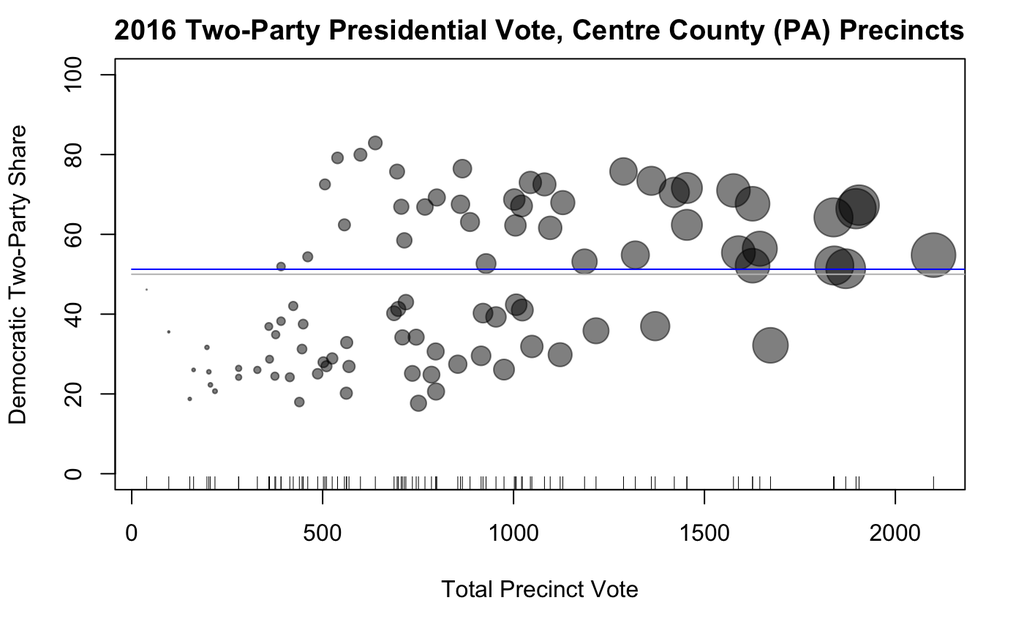

```r
lines(c(0,5000),c(50,50), col="gray")
rug(Ex3Data$Tot)
```

Here, we examine rolloff from President to Auditor, plotted again against precinct size. We see most precincts relatively close to the County Average (of 3.86%), but with some deviations, including one negative value.

In the precinct of “Rush East,” there were 97 total votes cast, with 95 cast for Auditor (50.5% for the Democrat), but only 91 votes cast for President (35.2% for the Democrat, Hillary Clinton). Such outliers are more likely with relative small number of voters.

```r
plot(Ex3Data$Tot,Ex3Data$ROAud,cex=1, pch=19, col=rgb(0,0,0,.5), main="Ballot Rolloff, President to Auditor General",sub= "Centre County (PA) Precincts",xlab="Total Precinct Vote",ylab="Democratic Two-Party Share", ylim=c(-10,10))
CountyVPre <- sum(rawdata$Count[rawdata$Contest=="PRESIDENTIAL ELECTORS"], na.rm=TRUE)
CountyVAud <- sum(rawdata$Count[rawdata$Contest=="AUDITOR GENERAL"], na.rm=TRUE)
#CountyRVPre <- sum(rawdata$Count[rawdata$Contest=="PRESIDENTIAL ELECTORS" & rawdata$Party=="REPUBLICAN"], na.rm=TRUE)
CountyROAud <- 100*(1-CountyVAud/CountyVPre)
lines(c(0,5000),c(CountyROAud,CountyROAud), col="red")
```

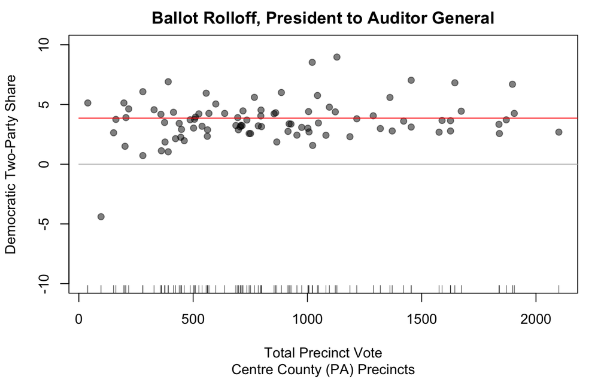

```r
lines(c(0,5000),c(0,0), col="gray")
rug(Ex3Data$Tot)
```